# RNA-seq workflow

## Set some paths

```r
## Set data directory. This is the path to unpacked STA426_RNAseq_input folder
data_dir <- "~/Dropbox/teaching_material/STA426lecture2016/for_students_input"
## data_dir <- "/Volumes/GroupsBio/Sta_426/RNAseq_workflow_files/input"

## Set output directory. If you want to generate output, it should be a directory where
## you have writing permission. If you just want to read the pre-generated output,
## it is the path to the unpacked STA426_RNAseq_output folder
## output_dir <- "~/Dropbox/teaching_material/STA426lecture2016/for_students_output"
output_dir <- "~/Desktop/STA426"
## output_dir <- "/Volumes/GroupsBio/Sta_426/RNAseq_workflow_files/output"

## Set paths to the software we will use. This will depend on your system. If you want to
## use the pre-generated output, you don't need to set these
path_to_fastqc <- "~/Documents/Software/FastQC_v0.11.5/fastqc"
##path_to_fastqc <- "/usr/local/course/bin/fastqc/fastqc"

path_to_hisat2_build <- "~/Documents/Software/hisat2-2.0.4/hisat2-build"
##path_to_hisat2_build <- "/usr/local/course/bin/hisat2-2.0.4/hisat2-build"

path_to_hisat2 <- "~/Documents/Software/hisat2-2.0.4/hisat2"
##path_to_hisat2 <- "/usr/local/course/bin/hisat2-2.0.4/hisat2"

path_to_samtools <- "samtools"
##path_to_samtools <- "/usr/local/course/bin/samtools"

path_to_salmon <- "DYLD_FALLBACK_LIBRARY_PATH=~/Documents/Software/Salmon-0.7.2_OSX_10.11/lib ~/Documents/Software/Salmon-0.7.2_OSX_10.11/bin/salmon"
```

```r
## If you want to generate output in the output directory, create some
## necessary subfolders
system(sprintf("mkdir -p %s/airway_chr18", output_dir))
system(sprintf("mkdir -p %s/airway_chr18/reference_chr18/hisat2_index", output_dir))
```

## Example data set

- RNA-seq experiment wherein airway smooth muscle cells were treated with dexamethasone (Himes 2014, PMID 24926665, GSE52778).
- Four human airway smooth muscle cell lines were treated with 1 micromolar dexamethasone for 18 hours.
- For each of the four cell lines, we have a treated and an untreated sample.
- All quantifications based on the Ensembl human reference genome, version GRCh37.75.

## Raw data

- Raw reads typically come as fastq files

```r
system(sprintf("head %s/airway_chr18/SRR1039508_chr18_1.fastq", data_dir))
```

## QC of raw data

- Check for low-quality data, remaining adapters, contamination, …
- [FastQC](http://www.bioinformatics.babraham.ac.uk/projects/fastqc/)

```r
(cmd <- paste0(path_to_fastqc, " -h"))
```

```
## [1] "~/Documents/Software/FastQC_v0.11.5/fastqc -h"
```

```r
system(cmd)
```

```r
(cmd <- sprintf("%s -o %s/airway_chr18 %s/airway_chr18/SRR1039508_chr18_1.fastq",
                path_to_fastqc,
                output_dir,
                data_dir))
```

```
## [1] "~/Documents/Software/FastQC_v0.11.5/fastqc -o ~/Desktop/STA426/airway_chr18 ~/Dropbox/teaching_material/STA426lecture2016/for_students_input/airway_chr18/SRR1039508_chr18_1.fastq"
```

```r
system(cmd)
```

```r
(cmd <- sprintf("%s -o %s/airway_chr18 %s/airway_chr18/SRR1039508_chr18_2.fastq",
                path_to_fastqc,
                output_dir,
                data_dir))
```

```
## [1] "~/Documents/Software/FastQC_v0.11.5/fastqc -o ~/Desktop/STA426/airway_chr18 ~/Dropbox/teaching_material/STA426lecture2016/for_students_input/airway_chr18/SRR1039508_chr18_2.fastq"
```

```r
system(cmd)
```

### If necessary, fix QC problems

- Most commonly: trim adapters
- More rarely: exclude or trim very low-quality sequences
- [cutadapt](http://cutadapt.readthedocs.io/en/stable/guide.html), [Trimmomatic](http://www.usadellab.org/cms/?page=trimmomatic), [FASTX-toolkit](http://hannonlab.cshl.edu/fastx_toolkit/)

## Reference files

- Needed to infer origin of read sequences
- [Ensembl](http://www.ensembl.org/info/data/ftp/index.html), [UCSC](http://hgdownload.cse.ucsc.edu/downloads.html), [iGenome](http://support.illumina.com/sequencing/sequencing_software/igenome.html)
- Alternative: [biomaRt](http://www.ensembl.org/biomart/martview). See a recent [tutorial](http://www.nxn.se/valent/2016/10/3/the-first-steps-in-rna-seq-expression-analysis-single-cell-and-other)

### Genomic sequence

- Typically in fasta format

```r
system(sprintf("head %s/airway_chr18/reference_chr18/Homo_sapiens.GRCh37.75.dna.chromosome.18.fa",
               data_dir))
system(sprintf("wc -l %s/airway_chr18/reference_chr18/Homo_sapiens.GRCh37.75.dna.chromosome.18.fa",
               data_dir))
```

### Transcript sequences

- Typically in fasta format

```r
system(sprintf("head %s/airway_chr18/reference_chr18/Homo_sapiens.GRCh37.75.cdna.chr18.fa",
               data_dir))
system(sprintf("wc -l %s/airway_chr18/reference_chr18/Homo_sapiens.GRCh37.75.cdna.chr18.fa",
               data_dir))
system(sprintf("grep '>' %s/airway_chr18/reference_chr18/Homo_sapiens.GRCh37.75.cdna.chr18.fa | wc -l",
               data_dir))
```

### Location of genomic features

- Typically in gtf or gff format

```r
system(sprintf("head %s/airway_chr18/reference_chr18/Homo_sapiens.GRCh37.75.chr18.gtf", data_dir))
```

## Genome alignment-based quantification approach

- Various aligners exist, e.g. [HISAT2](https://ccb.jhu.edu/software/hisat2/index.shtml), STAR, [TopHat2](https://ccb.jhu.edu/software/tophat/index.shtml)
- For genome alignment of RNA-seq data, important that the aligner allows gaps in the alignment (to accommodate reads spanning exon-exon junctions)

### Index reference genome for use with HISAT2

```r
(cmd <- paste0(path_to_hisat2_build, " -h"))
```

```
## [1] "~/Documents/Software/hisat2-2.0.4/hisat2-build -h"
```

```r
system(cmd)
```

```r
(cmd <- sprintf("%s -p 1 %s %s",
                path_to_hisat2_build,
                paste0(data_dir, "/airway_chr18/reference_chr18/Homo_sapiens.GRCh37.75.dna.chromosome.18.fa"),
                paste0(output_dir, "/airway_chr18/reference_chr18/hisat2_index/Homo_sapiens.GRCh37.75.dna.chromosome.18")))
```

```
## [1] "~/Documents/Software/hisat2-2.0.4/hisat2-build -p 1 ~/Dropbox/teaching_material/STA426lecture2016/for_students_input/airway_chr18/reference_chr18/Homo_sapiens.GRCh37.75.dna.chromosome.18.fa ~/Desktop/STA426/airway_chr18/reference_chr18/hisat2_index/Homo_sapiens.GRCh37.75.dna.chromosome.18"
```

```r
system(cmd)
```

### Align reads to the indexed genome with HISAT2

```r
(cmd <- paste0(path_to_hisat2, " -h"))
```

```
## [1] "~/Documents/Software/hisat2-2.0.4/hisat2 -h"
```

```r
system(cmd)
```

```r
(cmd <- sprintf("%s -x %s -1 %s -2 %s > %s",
                path_to_hisat2,
                paste0(output_dir, "/airway_chr18/reference_chr18/hisat2_index/Homo_sapiens.GRCh37.75.dna.chromosome.18"),
                paste0(data_dir, "/airway_chr18/SRR1039508_chr18_1.fastq"),
                paste0(data_dir, "/airway_chr18/SRR1039508_chr18_2.fastq"),
                paste0(output_dir, "/airway_chr18/SRR1039508_chr18_hisat2.sam")))
```

```
## [1] "~/Documents/Software/hisat2-2.0.4/hisat2 -x ~/Desktop/STA426/airway_chr18/reference_chr18/hisat2_index/Homo_sapiens.GRCh37.75.dna.chromosome.18 -1 ~/Dropbox/teaching_material/STA426lecture2016/for_students_input/airway_chr18/SRR1039508_chr18_1.fastq -2 ~/Dropbox/teaching_material/STA426lectu…
```

```r
system(cmd)
```

- Output from aligner typically in [SAM or BAM (binary SAM)](https://samtools.github.io/hts-specs/SAMv1.pdf) format

```r
system(sprintf("head %s/airway_chr18/SRR1039508_chr18_hisat2.sam", output_dir))
```

### Convert sam file to binary bam file and sort alignments

- [samtools](http://www.htslib.org/) is the standard library for manipulating SAM/BAM files

```r
(cmd <- sprintf("%s view -b %s | %s sort -T tmp -O bam - > %s",
                path_to_samtools,
                paste0(output_dir, "/airway_chr18/SRR1039508_chr18_hisat2.sam"),
                path_to_samtools,
                paste0(output_dir, "/airway_chr18/SRR1039508_chr18_hisat2.bam")))
```

```
## [1] "samtools view -b ~/Desktop/STA426/airway_chr18/SRR1039508_chr18_hisat2.sam | samtools sort -T tmp -O bam - > ~/Desktop/STA426/airway_chr18/SRR1039508_chr18_hisat2.bam"
```

```r
system(cmd)
```

### Index bam file

```r
(cmd <- sprintf("%s index %s/airway_chr18/SRR1039508_chr18_hisat2.bam",
                path_to_samtools,
                output_dir))
```

```
## [1] "samtools index ~/Desktop/STA426/airway_chr18/SRR1039508_chr18_hisat2.bam"
```

```r
system(cmd)
```

### Count number of reads overlapping each gene

- Several options available: [Rsubread/featureCounts](https://bioconductor.org/packages/release/bioc/html/Rsubread.html), [HTSeq-count](http://www-huber.embl.de/users/anders/HTSeq/doc/count.html), [summarizeOverlaps](https://bioconductor.org/packages/release/bioc/html/GenomicAlignments.html)

```r
library(Rsubread)
?featureCounts
fc <- featureCounts(files = path.expand(paste0(output_dir, "/airway_chr18/SRR1039508_chr18_hisat2.bam")),
                    annot.ext = path.expand(paste0(data_dir,
                                                   "/airway_chr18/reference_chr18/Homo_sapiens.GRCh37.75.chr18.gtf")),
                    isGTFAnnotationFile = TRUE, GTF.featureType = "exon",
                    GTF.attrType = "gene_id", useMetaFeatures = TRUE,
                    strandSpecific = 0, isPairedEnd = TRUE)
```

```
##
##         ==========     _____ _    _ ____  _____  ______          _____
##         =====         / ____| |  | |  _ \|  __ \|  ____|   /\   |  __ \
##           =====      | (___ | |  | | |_) | |__) | |__     /  \  | |  | |
##             ====      \___ \| |  | |  _ <|  _  /|  __|   / /\ \ | |  | |
##               ====    ____) | |__| | |_) | | \ \| |____ / ____ \| |__| |
##         ==========   |_____/ \____/|____/|_|  \_\______/_/    \_\_____/
##        Rsubread 1.22.3
##
## //========================== featureCounts setting ===========================\\
## ||                                                                            ||
## ||             Input files : 1 BAM file                                       ||
## ||                           P /Users/charlotte/Desktop/STA426/airway_chr ... ||
## ||                                                                            ||
## ||             Output file : ./.Rsubread_featureCounts_pid1677                ||
## ||                 Summary : ./.Rsubread_featureCounts_pid1677.summary        ||
## ||              Annotation : /Users/charlotte/Dropbox/teaching_material/S ... ||
## ||                                                                            ||
## ||                 Threads : 1                                                ||
## ||                   Level : meta-feature level                               ||
## ||              Paired-end : yes                                              ||
## ||         Strand specific : no                                               ||
## ||      Multimapping reads : not counted                                      ||
## || Multi-overlapping reads : not counted                                      ||
## ||                                                                            ||
## ||          Chimeric reads : counted                                          ||
## ||        Both ends mapped : not required                                     ||
## ||                                                                            ||
## \\===================== http://subread.sourceforge.net/ ======================//
##
## //================================= Running ==================================\\
## ||                                                                            ||
## || Load annotation file /Users/charlotte/Dropbox/teaching_material/STA426 ... ||
## ||    Features : 20401                                                        ||
## ||    Meta-features : 1127                                                    ||
## ||    Chromosomes/contigs : 1                                                 ||
## ||                                                                            ||
## || Process BAM file /Users/charlotte/Desktop/STA426/airway_chr18/SRR10395 ... ||
## ||    Paired-end reads are included.                                          ||
## ||    Assign fragments (read pairs) to features...                            ||
## ||                                                                            ||
## ||    WARNING: reads from the same pair were found not adjacent to each       ||
## ||             other in the input (due to read sorting by location or         ||
## ||             reporting of multi-mapping read pairs).                        ||
## ||                                                                            ||
## ||    Read re-ordering is performed.                                          ||
## ||                                                                            ||
## ||    Total fragments : 216671                                                ||
## ||    Successfully assigned fragments : 172319 (79.5%)                        ||
## ||    Running time : 0.01 minutes                                             ||
## ||                                                                            ||
## ||                         Read assignment finished.                          ||
## ||                                                                            ||
## \\===================== http://subread.sourceforge.net/ ======================//
```

```r
saveRDS(fc, file = paste0(output_dir, "/featureCounts.rds"))
```

```r
fc <- readRDS(paste0(output_dir, "/featureCounts.rds"))
names(fc)
```

```
## [1] "counts"     "annotation" "targets"    "stat"
```

```r
fc$stat
```

```
##                       Status
## 1                   Assigned
## 2       Unassigned_Ambiguity
## 3    Unassigned_MultiMapping
## 4      Unassigned_NoFeatures
## 5        Unassigned_Unmapped
## 6  Unassigned_MappingQuality
## 7  Unassigned_FragmentLength
## 8         Unassigned_Chimera
## 9       Unassigned_Secondary
## 10    Unassigned_Nonjunction
## 11      Unassigned_Duplicate
##    X.Users.charlotte.Desktop.STA426.airway_chr18.SRR1039508_chr18_hisat2.bam
## 1                                                                     172319
## 2                                                                      24163
## 3                                                                       2831
## 4                                                                      16423
## 5                                                                        935
## 6                                                                          0
## 7                                                                          0
## 8                                                                          0
## 9                                                                          0
## 10                                                                         0
## 11                                                                         0
```

```r
head(fc$counts)
```

```
##                 X.Users.charlotte.Desktop.STA426.airway_chr18.SRR1039508_chr18_hisat2.bam
## ENSG00000262352                                                                         0
## ENSG00000263305                                                                         0
## ENSG00000262181                                                                         0
## ENSG00000173213                                                                         2
## ENSG00000262081                                                                         0
## ENSG00000263006                                                                         7
```

## “Alignment-free” quantification approach

- Several options: [kallisto](https://pachterlab.github.io/kallisto/), [Salmon](https://combine-lab.github.io/salmon/), [Sailfish](http://www.cs.cmu.edu/~ckingsf/software/sailfish/)

```r
(cmd <- path_to_salmon)
```

```
## [1] "DYLD_FALLBACK_LIBRARY_PATH=~/Documents/Software/Salmon-0.7.2_OSX_10.11/lib ~/Documents/Software/Salmon-0.7.2_OSX_10.11/bin/salmon"
```

```r
system(cmd)
```

```r
(cmd <- paste0(path_to_salmon, " index -h"))
```

```
## [1] "DYLD_FALLBACK_LIBRARY_PATH=~/Documents/Software/Salmon-0.7.2_OSX_10.11/lib ~/Documents/Software/Salmon-0.7.2_OSX_10.11/bin/salmon index -h"
```

```r
system(cmd)
```

### Merge coding and noncoding RNA reference files

```r
(cmd <- sprintf("cat %s %s > %s",
                paste0(data_dir, "/airway_chr18/reference_chr18/Homo_sapiens.GRCh37.75.cdna.chr18.fa"),
                paste0(data_dir, "/airway_chr18/reference_chr18/Homo_sapiens.GRCh37.75.ncrna.chr18.fa"),
                paste0(output_dir, "/airway_chr18/reference_chr18/Homo_sapiens.GRCh37.75.cdna.ncrna.chr18.fa")))
```

```
## [1] "cat ~/Dropbox/teaching_material/STA426lecture2016/for_students_input/airway_chr18/reference_chr18/Homo_sapiens.GRCh37.75.cdna.chr18.fa ~/Dropbox/teaching_material/STA426lecture2016/for_students_input/airway_chr18/reference_chr18/Homo_sapiens.GRCh37.75.ncrna.chr18.fa > ~/Desktop/STA426/airway…
```

```r
system(cmd)
```

### Index reference transcriptome for use with Salmon

```r
(cmd <- sprintf("%s index -t %s -i %s -p 1",
                path_to_salmon,
                paste0(output_dir, "/airway_chr18/reference_chr18/Homo_sapiens.GRCh37.75.cdna.ncrna.chr18.fa"),
                paste0(output_dir, "/airway_chr18/reference_chr18/Homo_sapiens.GRCh37.75.cdna.ncrna.chr18.sidx")))
```

```
## [1] "DYLD_FALLBACK_LIBRARY_PATH=~/Documents/Software/Salmon-0.7.2_OSX_10.11/lib ~/Documents/Software/Salmon-0.7.2_OSX_10.11/bin/salmon index -t ~/Desktop/STA426/airway_chr18/reference_chr18/Homo_sapiens.GRCh37.75.cdna.ncrna.chr18.fa -i ~/Desktop/STA426/airway_chr18/reference_chr18/Homo_sapiens.GR…
```

```r
system(cmd)
```

### Quantify transcript abundances

```r
(cmd <- paste0(path_to_salmon, " quant --help-reads"))
```

```
## [1] "DYLD_FALLBACK_LIBRARY_PATH=~/Documents/Software/Salmon-0.7.2_OSX_10.11/lib ~/Documents/Software/Salmon-0.7.2_OSX_10.11/bin/salmon quant --help-reads"
```

```r
system(cmd)

(cmd <- sprintf("%s quant -i %s -l A -1 %s -2 %s -o %s -p 1",
                path_to_salmon,
                paste0(output_dir, "/airway_chr18/reference_chr18/Homo_sapiens.GRCh37.75.cdna.ncrna.chr18.sidx"),
                paste0(data_dir, "/airway_chr18/SRR1039508_chr18_1.fastq"),
                paste0(data_dir, "/airway_chr18/SRR1039508_chr18_2.fastq"),
                paste0(output_dir, "/airway_chr18/SRR1039508_chr18_salmon")))
```

```
## [1] "DYLD_FALLBACK_LIBRARY_PATH=~/Documents/Software/Salmon-0.7.2_OSX_10.11/lib ~/Documents/Software/Salmon-0.7.2_OSX_10.11/bin/salmon quant -i ~/Desktop/STA426/airway_chr18/reference_chr18/Homo_sapiens.GRCh37.75.cdna.ncrna.chr18.sidx -l A -1 ~/Dropbox/teaching_material/STA426lecture2016/for_stud…
```

```r
system(cmd)
```

```r
system(sprintf("head %s/airway_chr18/SRR1039508_chr18_salmon/quant.sf", output_dir))
```

### Generate transcript-to-gene mapping

- Needed to tell Salmon which transcripts stem from the same gene locus, and further to summarize abundances on the gene level

```r
system(sprintf("head %s/airway_chr18/reference_chr18/Homo_sapiens.GRCh37.75.cdna.ncrna.chr18.fa", output_dir))
```

```r
library(Biostrings)
## Read the fasta file in R using a function from the Biostrings package
cdna.ncrna <- readDNAStringSet(paste0(output_dir,
                                      "/airway_chr18/reference_chr18/Homo_sapiens.GRCh37.75.cdna.ncrna.chr18.fa"))

## Go through the sequence names and extract the required information
tx2gene <- data.frame(t(sapply(names(cdna.ncrna), function(nm) {
  tmp <- strsplit(nm, " ")[[1]]
  tx <- tmp[1]
  gene <- gsub("gene:", "", tmp[grep("^gene:", tmp)])
  c(tx = tx, gene = gene)
})), stringsAsFactors = FALSE)
rownames(tx2gene) <- NULL

head(tx2gene)
```

```
##                tx            gene
## 1 ENST00000489748 ENSG00000206072
## 2 ENST00000382749 ENSG00000206072
## 3 ENST00000467649 ENSG00000206072
## 4 ENST00000544088 ENSG00000206072
## 5 ENST00000538847 ENSG00000206072
## 6 ENST00000536691 ENSG00000206072
```

### Import abundance estimates into R and summarize on gene level

- Parse the text files output by Salmon and summarize the data for all samples into one abundance matrix

```r
library(tximport)
files <- paste0(output_dir, "/airway_chr18/SRR1039508_chr18_salmon/quant.sf")
names(files) <- "SRR1039508"
files
```

```
##                                                       SRR1039508
## "~/Desktop/STA426/airway_chr18/SRR1039508_chr18_salmon/quant.sf"
```

```r
txi <- tximport(files = files, type = "salmon", tx2gene = tx2gene)
```

```
## reading in files
```

```
## 1
```

```
## summarizing abundance
```

```
## summarizing counts
```

```
## summarizing length
```

```r
names(txi)
```

```
## [1] "abundance"           "counts"              "length"
## [4] "countsFromAbundance"
```

```r
head(txi$counts)
```

```
##                 SRR1039508
## ENSG00000017797  2886.9964
## ENSG00000041353    41.0000
## ENSG00000046604    22.3531
## ENSG00000049759  1788.9055
## ENSG00000053747   925.9998
## ENSG00000057149     0.0000
```

### Compare gene counts from the two approaches

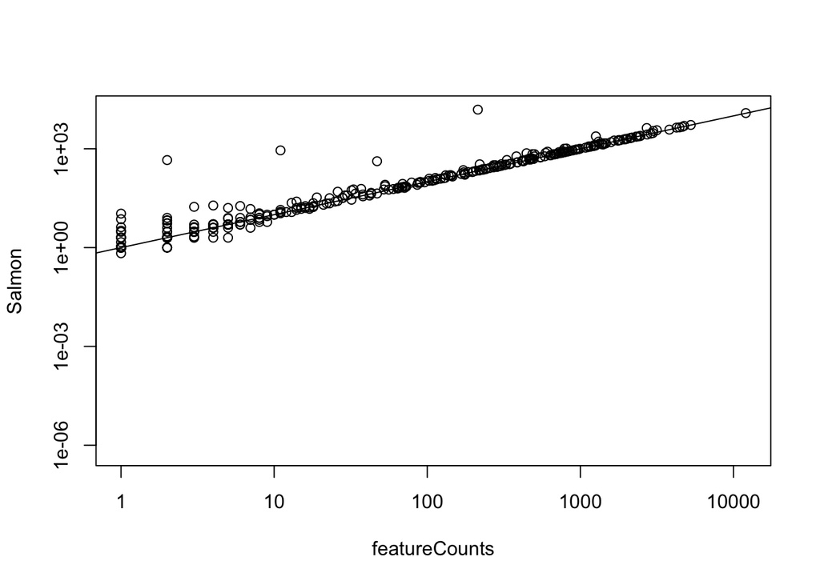

```r
plot(fc$counts, txi$counts[match(rownames(fc$counts), rownames(txi$counts))],
     log = "xy", xlab = "featureCounts", ylab = "Salmon")
abline(0, 1)
```

```r
rn <- rownames(fc$counts[order(fc$counts - txi$counts[match(rownames(fc$counts),
                                                            rownames(txi$counts))])[1:4], , drop = FALSE])
rn
```

```
## [1] "ENSG00000265681" "ENSG00000171451" "ENSG00000215492" "ENSG00000178127"
```

```r
txi$counts[rn, ]
```

```
## ENSG00000265681 ENSG00000171451 ENSG00000215492 ENSG00000178127
##      15456.3191       4274.1000       2390.8300        895.1512
```

```r
fc$counts[rn, ]
```

```
## ENSG00000265681 ENSG00000171451 ENSG00000215492 ENSG00000178127
##             214            2712            1262              11
```

```r
colSums(txi$counts)
```

```
## SRR1039508
##     198203
```

```r
colSums(fc$counts)
```

```
## X.Users.charlotte.Desktop.STA426.airway_chr18.SRR1039508_chr18_hisat2.bam
##                                                                    172319
```

## Load counts and tx2gene mapping for full data set

```r
dirs <- list.files(paste0(data_dir, "/airway_full/salmon"), full.names = TRUE)
files <- paste0(dirs, "/quant.sf")
names(files) <- basename(dirs)
files
```

```
##                                                                                                               SRR1039508
## "/Users/charlotte/Dropbox/teaching_material/STA426lecture2016/for_students_input/airway_full/salmon/SRR1039508/quant.sf"
##                                                                                                               SRR1039509
## "/Users/charlotte/Dropbox/teaching_material/STA426lecture2016/for_students_input/airway_full/salmon/SRR1039509/quant.sf"
##                                                                                                               SRR1039512
## "/Users/charlotte/Dropbox/teaching_material/STA426lecture2016/for_students_input/airway_full/salmon/SRR1039512/quant.sf"
##                                                                                                               SRR1039513
## "/Users/charlotte/Dropbox/teaching_material/STA426lecture2016/for_students_input/airway_full/salmon/SRR1039513/quant.sf"
##                                                                                                               SRR1039516
## "/Users/charlotte/Dropbox/teaching_material/STA426lecture2016/for_students_input/airway_full/salmon/SRR1039516/quant.sf"
##                                                                                                               SRR1039517
## "/Users/charlotte/Dropbox/teaching_material/STA426lecture2016/for_students_input/airway_full/salmon/SRR1039517/quant.sf"
##                                                                                                               SRR1039520
## "/Users/charlotte/Dropbox/teaching_material/STA426lecture2016/for_students_input/airway_full/salmon/SRR1039520/quant.sf"
##                                                                                                               SRR1039521
## "/Users/charlotte/Dropbox/teaching_material/STA426lecture2016/for_students_input/airway_full/salmon/SRR1039521/quant.sf"
```

```r
tx2gene <- readRDS(paste0(data_dir, "/airway_full/Homo_sapiens.GRCh37.75.cdna.ncrna.tx2gene.rds"))
txi <- tximport(files = files, type = "salmon", tx2gene = tx2gene)
```

```
## reading in files
```

```
## 1
```

```
## 2
```

```
## 3
```

```
## 4
```

```
## 5
```

```
## 6
```

```
## 7
```

```
## 8
```

```
## summarizing abundance
```

```
## summarizing counts
```

```
## summarizing length
```

```r
head(txi$counts)
```

```
##                 SRR1039508 SRR1039509 SRR1039512 SRR1039513 SRR1039516
## ENSG00000000003  697.58860  458.97716  893.27802  419.09372  1151.7832
## ENSG00000000005    0.00000    0.00000    0.00000    0.00000     0.0000
## ENSG00000000419  465.99971  515.59790  624.99950  365.68210   590.0998
## ENSG00000000457  332.19170  282.54461  381.22100  228.05711   374.4514
## ENSG00000000460   89.69806   74.17516   64.07818   49.05461   118.5707
## ENSG00000000938    0.00000    0.00000    2.00000    0.00000     1.0000
##                 SRR1039517 SRR1039520 SRR1039521
## ENSG00000000003  1074.9627   778.5233  586.28318
## ENSG00000000005     0.0000     0.0000    0.00000
## ENSG00000000419   797.9875   419.6749  510.91927
## ENSG00000000457   470.9977   317.8293  298.29453
## ENSG00000000460   107.5191   102.5223   85.14676
## ENSG00000000938     0.0000     0.0000    0.00000
```

```r
colSums(txi$counts)
```

```
## SRR1039508 SRR1039509 SRR1039512 SRR1039513 SRR1039516 SRR1039517
##   21649983   19797270   26680359   16035927   25769334   32524574
## SRR1039520 SRR1039521
##   20141426   22349685
```

## Generate DGEList

- Stores all necessary information about the experiment in a single object - easier to keep track and offers control mechanisms
- Other packages than [edgeR](http://bioconductor.org/packages/release/bioc/html/edgeR.html) (which we will use here) use other objects (e.g., DESeqDataSet for [DESeq2](http://bioconductor.org/packages/release/bioc/html/DESeq2.html))

```r
library(edgeR)
dge <- DGEList(counts = txi$counts, genes = data.frame(gene.id = rownames(txi$counts)))
dge
```

```
## An object of class "DGEList"
## $counts
##                 SRR1039508 SRR1039509 SRR1039512 SRR1039513 SRR1039516
## ENSG00000000003  697.58860  458.97716  893.27802  419.09372  1151.7832
## ENSG00000000005    0.00000    0.00000    0.00000    0.00000     0.0000
## ENSG00000000419  465.99971  515.59790  624.99950  365.68210   590.0998
## ENSG00000000457  332.19170  282.54461  381.22100  228.05711   374.4514
## ENSG00000000460   89.69806   74.17516   64.07818   49.05461   118.5707
##                 SRR1039517 SRR1039520 SRR1039521
## ENSG00000000003  1074.9627   778.5233  586.28318
## ENSG00000000005     0.0000     0.0000    0.00000
## ENSG00000000419   797.9875   419.6749  510.91927
## ENSG00000000457   470.9977   317.8293  298.29453
## ENSG00000000460   107.5191   102.5223   85.14676
## 63672 more rows ...
##
## $samples
##            group lib.size norm.factors
## SRR1039508     1 21649983            1
## SRR1039509     1 19797270            1
## SRR1039512     1 26680359            1
## SRR1039513     1 16035927            1
## SRR1039516     1 25769334            1
## SRR1039517     1 32524574            1
## SRR1039520     1 20141426            1
## SRR1039521     1 22349685            1
##
## $genes
## [1] ENSG00000000003 ENSG00000000005 ENSG00000000419 ENSG00000000457
## [5] ENSG00000000460
## 63677 Levels: ENSG00000000003 ENSG00000000005 ... ENSG00000273493
## 63672 more rows ...
```

## Add additional gene identifiers

```r
library(AnnotationDbi)
library(Homo.sapiens)
columns(Homo.sapiens)
```

```
##  [1] "ACCNUM"       "ALIAS"        "CDSCHROM"     "CDSEND"
##  [5] "CDSID"        "CDSNAME"      "CDSSTART"     "CDSSTRAND"
##  [9] "DEFINITION"   "ENSEMBL"      "ENSEMBLPROT"  "ENSEMBLTRANS"
## [13] "ENTREZID"     "ENZYME"       "EVIDENCE"     "EVIDENCEALL"
## [17] "EXONCHROM"    "EXONEND"      "EXONID"       "EXONNAME"
## [21] "EXONRANK"     "EXONSTART"    "EXONSTRAND"   "GENEID"
## [25] "GENENAME"     "GO"           "GOALL"        "GOID"
## [29] "IPI"          "MAP"          "OMIM"         "ONTOLOGY"
## [33] "ONTOLOGYALL"  "PATH"         "PFAM"         "PMID"
## [37] "PROSITE"      "REFSEQ"       "SYMBOL"       "TERM"
## [41] "TXCHROM"      "TXEND"        "TXID"         "TXNAME"
## [45] "TXSTART"      "TXSTRAND"     "TXTYPE"       "UCSCKG"
## [49] "UNIGENE"      "UNIPROT"
```

```r
dge$genes$symbol <- mapIds(Homo.sapiens,
                           keys = as.character(dge$genes$gene.id),
                           column = "SYMBOL",
                           keytype = "ENSEMBL",
                           multiVals = "first")
dge$genes$entrez <- mapIds(Homo.sapiens,
                           keys = as.character(dge$genes$gene.id),
                           column = "ENTREZID",
                           keytype = "ENSEMBL",
                           multiVals = "first")
## Alternative solution
library(biomaRt)
ensembl <- useMart(biomart = "ENSEMBL_MART_ENSEMBL",
                   dataset="hsapiens_gene_ensembl", host = "www.ensembl.org")
convtable <- getBM(ensembl, attributes = c("ensembl_gene_id", "entrezgene", "hgnc_symbol"),
                   filters = "ensembl_gene_id", values = as.character(dge$genes$gene.id))
dge$genes$symbol <- convtable$hgnc_symbol[match(dge$genes$gene.id, convtable$ensembl_gene_id)]
dge$genes$entrez <- convtable$entrezgene[match(dge$genes$gene.id, convtable$ensembl_gene_id)]

head(dge$genes)
```

```
##           gene.id   symbol entrez
## 1 ENSG00000000003   TSPAN6   7105
## 2 ENSG00000000005     TNMD  64102
## 3 ENSG00000000419     DPM1   8813
## 4 ENSG00000000457    SCYL3  57147
## 5 ENSG00000000460 C1orf112  55732
## 6 ENSG00000000938      FGR   2268
```

## Calculate normalization factors

```r
dge <- calcNormFactors(dge)
dge
```

```
## An object of class "DGEList"
## $counts
##                 SRR1039508 SRR1039509 SRR1039512 SRR1039513 SRR1039516
## ENSG00000000003  697.58860  458.97716  893.27802  419.09372  1151.7832
## ENSG00000000005    0.00000    0.00000    0.00000    0.00000     0.0000
## ENSG00000000419  465.99971  515.59790  624.99950  365.68210   590.0998
## ENSG00000000457  332.19170  282.54461  381.22100  228.05711   374.4514
## ENSG00000000460   89.69806   74.17516   64.07818   49.05461   118.5707
##                 SRR1039517 SRR1039520 SRR1039521
## ENSG00000000003  1074.9627   778.5233  586.28318
## ENSG00000000005     0.0000     0.0000    0.00000
## ENSG00000000419   797.9875   419.6749  510.91927
## ENSG00000000457   470.9977   317.8293  298.29453
## ENSG00000000460   107.5191   102.5223   85.14676
## 63672 more rows ...
##
## $samples
##            group lib.size norm.factors
## SRR1039508     1 21649983    1.0587195
## SRR1039509     1 19797270    1.0275852
## SRR1039512     1 26680359    0.9805421
## SRR1039513     1 16035927    0.9631258
## SRR1039516     1 25769334    1.0227130
## SRR1039517     1 32524574    0.9583711
## SRR1039520     1 20141426    1.0372196
## SRR1039521     1 22349685    0.9574009
##
## $genes
##           gene.id   symbol entrez
## 1 ENSG00000000003   TSPAN6   7105
## 2 ENSG00000000005     TNMD  64102
## 3 ENSG00000000419     DPM1   8813
## 4 ENSG00000000457    SCYL3  57147
## 5 ENSG00000000460 C1orf112  55732
## 63672 more rows ...
```

## Add additional metadata

```r
meta <- read.delim(paste0(data_dir, "/airway_full/airway_meta.txt"), header = TRUE, as.is = TRUE)
meta
```

```
##   SampleName    cell   dex albut        Run avgLength Experiment    Sample
## 1 GSM1275862  N61311 untrt untrt SRR1039508       126  SRX384345 SRS508568
## 2 GSM1275863  N61311   trt untrt SRR1039509       126  SRX384346 SRS508567
## 3 GSM1275866 N052611 untrt untrt SRR1039512       126  SRX384349 SRS508571
## 4 GSM1275867 N052611   trt untrt SRR1039513        87  SRX384350 SRS508572
## 5 GSM1275870 N080611 untrt untrt SRR1039516       120  SRX384353 SRS508575
## 6 GSM1275871 N080611   trt untrt SRR1039517       126  SRX384354 SRS508576
## 7 GSM1275874 N061011 untrt untrt SRR1039520       101  SRX384357 SRS508579
## 8 GSM1275875 N061011   trt untrt SRR1039521        98  SRX384358 SRS508580
##      BioSample
## 1 SAMN02422669
## 2 SAMN02422675
## 3 SAMN02422678
## 4 SAMN02422670
## 5 SAMN02422682
## 6 SAMN02422673
## 7 SAMN02422683
## 8 SAMN02422677
```

```r
dge$samples <- merge(dge$samples, meta[, c("Run", "cell", "dex")],
                     by.x = 0, by.y = "Run", all = TRUE)
dge$samples$dex <- relevel(factor(dge$samples$dex), ref = "untrt")
dge
```

```
## An object of class "DGEList"
## $counts
##                 SRR1039508 SRR1039509 SRR1039512 SRR1039513 SRR1039516
## ENSG00000000003  697.58860  458.97716  893.27802  419.09372  1151.7832
## ENSG00000000005    0.00000    0.00000    0.00000    0.00000     0.0000
## ENSG00000000419  465.99971  515.59790  624.99950  365.68210   590.0998
## ENSG00000000457  332.19170  282.54461  381.22100  228.05711   374.4514
## ENSG00000000460   89.69806   74.17516   64.07818   49.05461   118.5707
##                 SRR1039517 SRR1039520 SRR1039521
## ENSG00000000003  1074.9627   778.5233  586.28318
## ENSG00000000005     0.0000     0.0000    0.00000
## ENSG00000000419   797.9875   419.6749  510.91927
## ENSG00000000457   470.9977   317.8293  298.29453
## ENSG00000000460   107.5191   102.5223   85.14676
## 63672 more rows ...
##
## $samples
##    Row.names group lib.size norm.factors    cell   dex
## 1 SRR1039508     1 21649983    1.0587195  N61311 untrt
## 2 SRR1039509     1 19797270    1.0275852  N61311   trt
## 3 SRR1039512     1 26680359    0.9805421 N052611 untrt
## 4 SRR1039513     1 16035927    0.9631258 N052611   trt
## 5 SRR1039516     1 25769334    1.0227130 N080611 untrt
## 6 SRR1039517     1 32524574    0.9583711 N080611   trt
## 7 SRR1039520     1 20141426    1.0372196 N061011 untrt
## 8 SRR1039521     1 22349685    0.9574009 N061011   trt
##
## $genes
##           gene.id   symbol entrez
## 1 ENSG00000000003   TSPAN6   7105
## 2 ENSG00000000005     TNMD  64102
## 3 ENSG00000000419     DPM1   8813
## 4 ENSG00000000457    SCYL3  57147
## 5 ENSG00000000460 C1orf112  55732
## 63672 more rows ...
```

## Filter out lowly expressed genes

- Different filter criteria are possible, but should be independent of the test statistic under the null hypothesis (in particular, should not involve use of the sample annotations)

```r
cpm <- cpm(dge)
dge <- dge[which(rowSums(cpm > 0.5) > 4), , keep.lib.sizes = FALSE]
dge <- calcNormFactors(dge)
```

## Estimate dispersion

```r
(design <- model.matrix(~cell + dex, data = dge$samples))
```

```
##   (Intercept) cellN061011 cellN080611 cellN61311 dextrt
## 1           1           0           0          1      0
## 2           1           0           0          1      1
## 3           1           0           0          0      0
## 4           1           0           0          0      1
## 5           1           0           1          0      0
## 6           1           0           1          0      1
## 7           1           1           0          0      0
## 8           1           1           0          0      1
## attr(,"assign")
## [1] 0 1 1 1 2
## attr(,"contrasts")
## attr(,"contrasts")$cell
## [1] "contr.treatment"
##
## attr(,"contrasts")$dex
## [1] "contr.treatment"
```

```r
dge <- estimateDisp(dge, design = design)
dge
```

```
## An object of class "DGEList"
## $counts
##                 SRR1039508 SRR1039509 SRR1039512 SRR1039513 SRR1039516
## ENSG00000000003  697.58860  458.97716  893.27802  419.09372  1151.7832
## ENSG00000000419  465.99971  515.59790  624.99950  365.68210   590.0998
## ENSG00000000457  332.19170  282.54461  381.22100  228.05711   374.4514
## ENSG00000000460   89.69806   74.17516   64.07818   49.05461   118.5707
## ENSG00000000971 3297.05046 3746.14664 6231.62130 4298.73542  6777.5104
##                 SRR1039517 SRR1039520 SRR1039521
## ENSG00000000003  1074.9627   778.5233  586.28318
## ENSG00000000419   797.9875   419.6749  510.91927
## ENSG00000000457   470.9977   317.8293  298.29453
## ENSG00000000460   107.5191   102.5223   85.14676
## ENSG00000000971 11111.4605  5225.0785 8072.03900
## 16793 more rows ...
##
## $samples
##    Row.names group lib.size norm.factors    cell   dex
## 1 SRR1039508     1 21576877    1.0565501  N61311 untrt
## 2 SRR1039509     1 19733772    1.0239426  N61311   trt
## 3 SRR1039512     1 26599776    0.9930210 N052611 untrt
## 4 SRR1039513     1 15992037    0.9442234 N052611   trt
## 5 SRR1039516     1 25686669    1.0321477 N080611 untrt
## 6 SRR1039517     1 32428935    0.9723344 N080611   trt
## 7 SRR1039520     1 20063635    1.0303943 N061011 untrt
## 8 SRR1039521     1 22278375    0.9533231 N061011   trt
##
## $genes
##           gene.id   symbol entrez
## 1 ENSG00000000003   TSPAN6   7105
## 3 ENSG00000000419     DPM1   8813
## 4 ENSG00000000457    SCYL3  57147
## 5 ENSG00000000460 C1orf112  55732
## 7 ENSG00000000971      CFH   3075
## 16793 more rows ...
##
## $common.dispersion
## [1] 0.01463254
##
## $trended.dispersion
## [1] 0.01046277 0.01147486 0.01414287 0.03407752 0.01102909
## 16793 more elements ...
##
## $tagwise.dispersion
## [1] 0.005659441 0.006850658 0.007253737 0.024733824 0.008022933
## 16793 more elements ...
##
## $AveLogCPM
## [1] 5.015956 4.542648 3.873202 1.943738 8.030859
## 16793 more elements ...
##
## $trend.method
## [1] "locfit"
##
## $prior.df
## [1] 3.888317
##
## $prior.n
## [1] 1.296106
##
## $span
## [1] 0.2909183
```

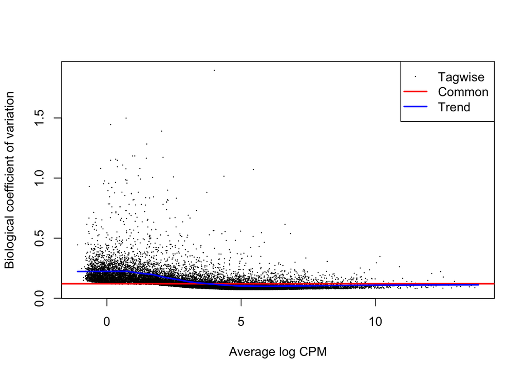

```r
plotBCV(dge)
```

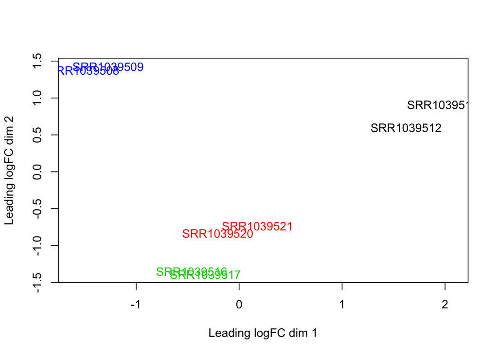

```r
plotMDS(dge, col = as.numeric(factor(dge$samples$cell)))
```

## Fit model and test

```r
## Quasi-likelihood test
fit <- glmQLFit(dge, design = design, robust = TRUE)
qlf <- glmQLFTest(fit, coef = "dextrt")

## Alt: Likelihood ratio test
## fit <- glmFit(dge, design = design)
## lrt <- glmLRT(fit, coef = "dextrt")

tt <- topTags(qlf, n = Inf)
head(tt$table)
```

```
##               gene.id symbol entrez     logFC   logCPM         F
## 11864 ENSG00000165995 CACNB2    783  3.282555 4.607727 1667.6501
## 3751  ENSG00000109906 ZBTB16   7704  5.506478 4.117099 1492.1425
## 10867 ENSG00000162493   PDPN  10630  1.873402 5.624631  909.2539
## 8911  ENSG00000146250 PRSS35 167681 -2.745488 3.845147  881.4150
## 9929  ENSG00000154930  ACSS1  84532  1.881150 4.904113  777.0120
## 10186 ENSG00000157214 STEAP2 261729  1.951171 7.097385  712.9620
##             PValue          FDR
## 11864 5.114070e-10 6.482047e-06
## 3751  7.717642e-10 6.482047e-06
## 10867 4.812243e-09 2.266530e-05
## 8911  5.397142e-09 2.266530e-05
## 9929  8.590405e-09 2.421768e-05
## 10186 1.179307e-08 2.421768e-05
```

## Write results to file

```r
write.table(tt$table, file = paste0(output_dir, "/DGE_results_edgeR.txt"),
            row.names = FALSE, col.names = TRUE, quote = FALSE, sep = "\t")
```

## Diagnostics: p-value histogram

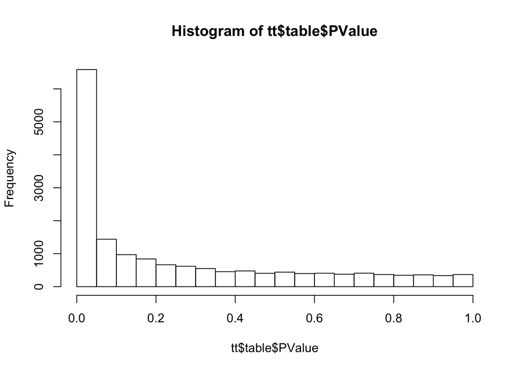

```r
hist(tt$table$PValue)
```

## Find differentially expressed genes

```r
is.de <- decideTestsDGE(qlf, p.value = 0.05)
summary(is.de)
```

```
##    [,1]
## -1  2122
## 0  12312
## 1   2364
```

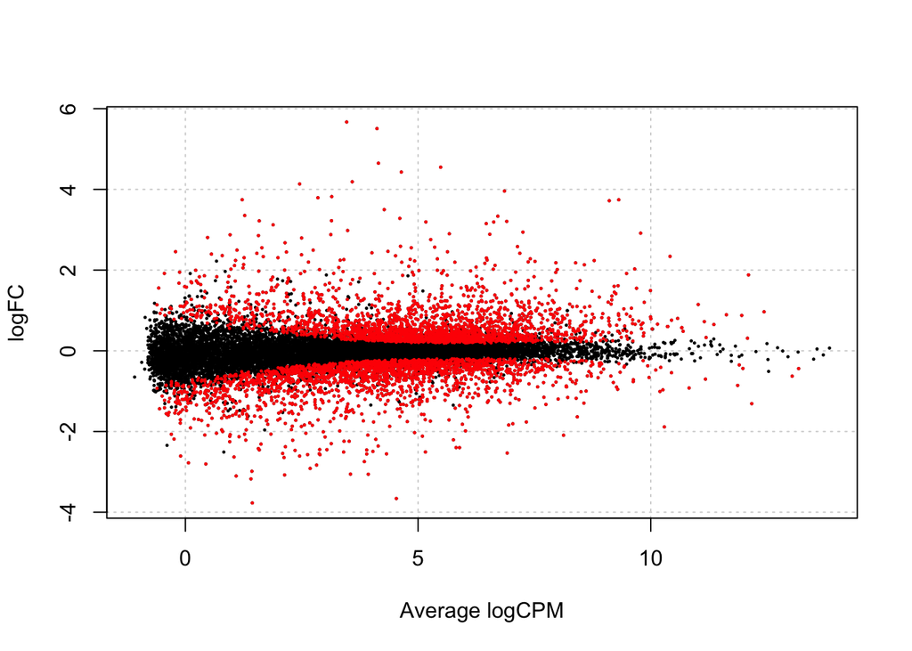

```r
plotSmear(qlf, de.tags = rownames(qlf)[is.de != 0])
```

### Visualize a few of the differentially expressed genes

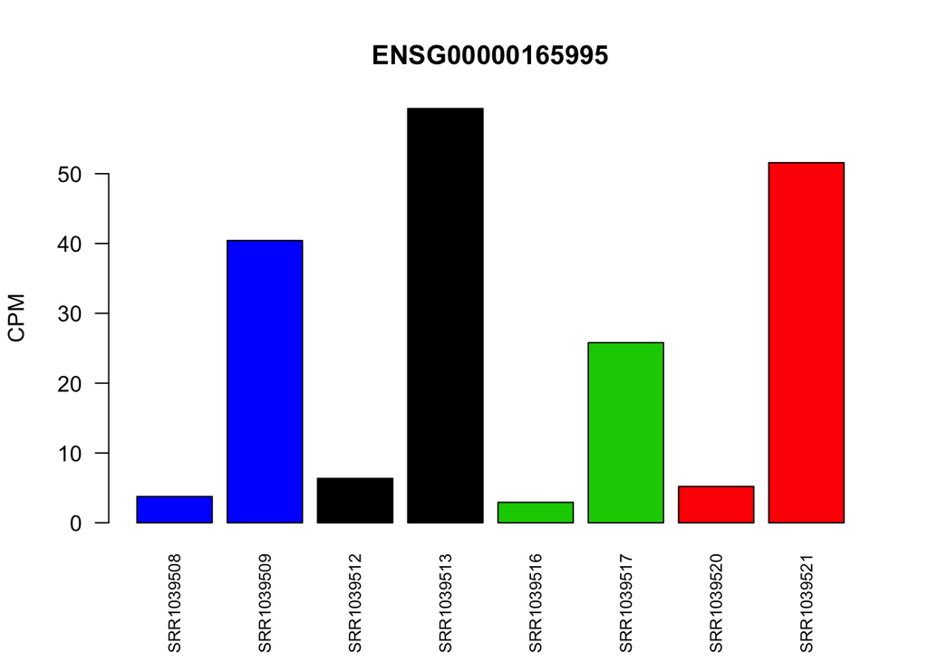

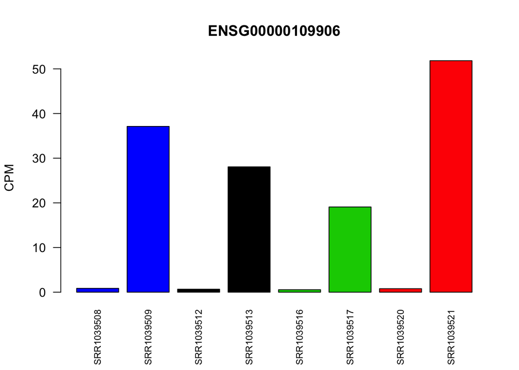

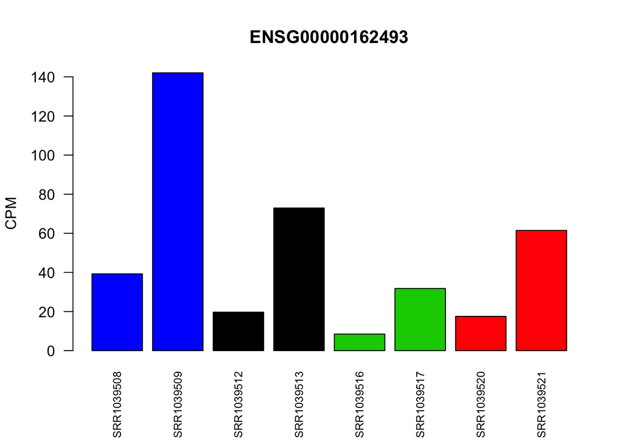

```r
for (i in tt$table$gene.id[1:3]) {
  barplot(cpm[i, ], col = as.numeric(factor(dge$samples$cell)),
          las = 2, cex.names = 0.75, main = i, ylab = "CPM")
}
```

## Gene set analysis (functional analysis)

- Gene sets represent groups of genes that are “related” in some (well-defined) way. They can be obtained e.g. from [mSigDB](http://software.broadinstitute.org/gsea/msigdb/), [GO (Gene Ontology)](http://geneontology.org/), [KEGG](http://www.genome.jp/kegg/).
- Distinction between competitive and self-contained tests ([Goeman & Bühlmann](http://bioinformatics.oxfordjournals.org/content/23/8/980))

```r
hallmarks <- readRDS(paste0(data_dir, "/hallmarks_entrez.rds"))
head(hallmarks)
```

```
## $HALLMARK_TNFA_SIGNALING_VIA_NFKB
##   [1]   3726   2920    467   4792   7128   5743   2919   8870   9308   6364
##  [11]   2921  23764   4791   7127   1839   1316    330   5329   7538   3383
##  [21]   3725   1960   3553    597  23645  80149   6648   4929   3552   5971
##  [31]   7185   7832   1843   1326   2114   2152   6385   1958   3569   7124
##  [41]  23135   4790   3976   5806   8061   3164    182   6351   2643   6347
##  [51]   1827   1844  10938   9592   5966   8837   8767   4794   8013  22822
##  [61]  51278   8744   2669   1647   3627  10769   8553   1959   9021  11182
##  [71]   5734   1847   5055   4783   5054  10221  25976   5970    329   6372
##  [81]   9516   7130    960   3624   5328   4609   3604   6446  10318  10135
##  [91]   2355  10957   3398    969   3575   1942   7262   5209   6352  79693
## [101]   3460   8878  10950   4616   8942  50486    694   4170   7422   5606
## [111]   1026   3491  10010   3433   3606   7280   3659   2353   4973    388
## [121]    374   4814  65986   8613   9314   6373   6303   1435   1880  56937
## [131]   5791   7097  57007   7071   4082   3914   1051   9322   2150    687
```

[output cut: 73 more lines]

```r
dge$counts <- round(dge$counts)
gstest <- camera(dge, index = ids2indices(hallmarks, dge$genes$entrez), design = design)
gstest
```

```
##                                            NGenes Direction       PValue
## HALLMARK_ADIPOGENESIS                         190        Up 3.130958e-05
## HALLMARK_ANDROGEN_RESPONSE                     92        Up 2.015427e-03
## HALLMARK_TNFA_SIGNALING_VIA_NFKB              179        Up 6.710375e-03
## HALLMARK_P53_PATHWAY                          191      Down 1.936767e-02
## HALLMARK_REACTIVE_OXIGEN_SPECIES_PATHWAY       49        Up 3.239565e-02
## HALLMARK_UV_RESPONSE_DN                       143        Up 3.350584e-02
## HALLMARK_OXIDATIVE_PHOSPHORYLATION            202        Up 3.732183e-02
## HALLMARK_E2F_TARGETS                          208      Down 4.061281e-02
## HALLMARK_COMPLEMENT                           153        Up 4.156182e-02
## HALLMARK_FATTY_ACID_METABOLISM                138        Up 4.361279e-02
## HALLMARK_INTERFERON_ALPHA_RESPONSE            107      Down 4.404169e-02
## HALLMARK_IL2_STAT5_SIGNALING                  159        Up 5.575010e-02
## HALLMARK_WNT_BETA_CATENIN_SIGNALING            36        Up 5.762296e-02
## HALLMARK_HEDGEHOG_SIGNALING                    26      Down 6.341570e-02
## HALLMARK_UV_RESPONSE_UP                       148        Up 7.386762e-02
## HALLMARK_ANGIOGENESIS                          26      Down 7.492342e-02
## HALLMARK_HYPOXIA                              176        Up 9.586827e-02
## HALLMARK_XENOBIOTIC_METABOLISM                167        Up 9.650442e-02
## HALLMARK_MYC_TARGETS_V2                        57        Up 1.001981e-01
## HALLMARK_PROTEIN_SECRETION                     91        Up 1.096800e-01
## HALLMARK_BILE_ACID_METABOLISM                  82        Up 1.349083e-01
## HALLMARK_INTERFERON_GAMMA_RESPONSE            209      Down 1.477053e-01
## HALLMARK_CHOLESTEROL_HOMEOSTASIS               69        Up 1.730330e-01
## HALLMARK_MYC_TARGETS_V1                       209        Up 2.072357e-01
## HALLMARK_IL6_JAK_STAT3_SIGNALING               62        Up 2.165791e-01
## HALLMARK_INFLAMMATORY_RESPONSE                143        Up 2.354586e-01
## HALLMARK_MTORC1_SIGNALING                     193      Down 2.997331e-01
## HALLMARK_MITOTIC_SPINDLE                      195        Up 3.043631e-01
## HALLMARK_APICAL_JUNCTION                      162        Up 3.059946e-01
## HALLMARK_UNFOLDED_PROTEIN_RESPONSE            112        Up 3.134366e-01
## HALLMARK_KRAS_SIGNALING_UP                    145      Down 3.616791e-01
## HALLMARK_PEROXISOME                            87        Up 3.883961e-01
## HALLMARK_TGF_BETA_SIGNALING                    52        Up 4.232445e-01
## HALLMARK_ALLOGRAFT_REJECTION                  153      Down 4.350433e-01
## HALLMARK_ESTROGEN_RESPONSE_EARLY              160        Up 4.368421e-01
## HALLMARK_DNA_REPAIR                           156      Down 5.031186e-01
## HALLMARK_COAGULATION                           99        Up 6.149424e-01
## HALLMARK_EPITHELIAL_MESENCHYMAL_TRANSITION    193      Down 6.844600e-01
## HALLMARK_PANCREAS_BETA_CELLS                   19        Up 7.393367e-01
```

[output cut: 47 more lines]

```
## HALLMARK_DNA_REPAIR                        0.698775796
## HALLMARK_COAGULATION                       0.831003234
## HALLMARK_EPITHELIAL_MESENCHYMAL_TRANSITION 0.900605273
## HALLMARK_PANCREAS_BETA_CELLS               0.933149172
## HALLMARK_KRAS_SIGNALING_DN                 0.933149172
## HALLMARK_APICAL_SURFACE                    0.933149172
## HALLMARK_NOTCH_SIGNALING                   0.933149172
## HALLMARK_G2M_CHECKPOINT                    0.933149172
## HALLMARK_PI3K_AKT_MTOR_SIGNALING           0.958109293
## HALLMARK_SPERMATOGENESIS                   0.958109293
## HALLMARK_GLYCOLYSIS                        0.958109293
## HALLMARK_HEME_METABOLISM                   0.958109293
## HALLMARK_MYOGENESIS                        0.958109293
## HALLMARK_APOPTOSIS                         0.990941436
## HALLMARK_ESTROGEN_RESPONSE_LATE            0.990941436
```

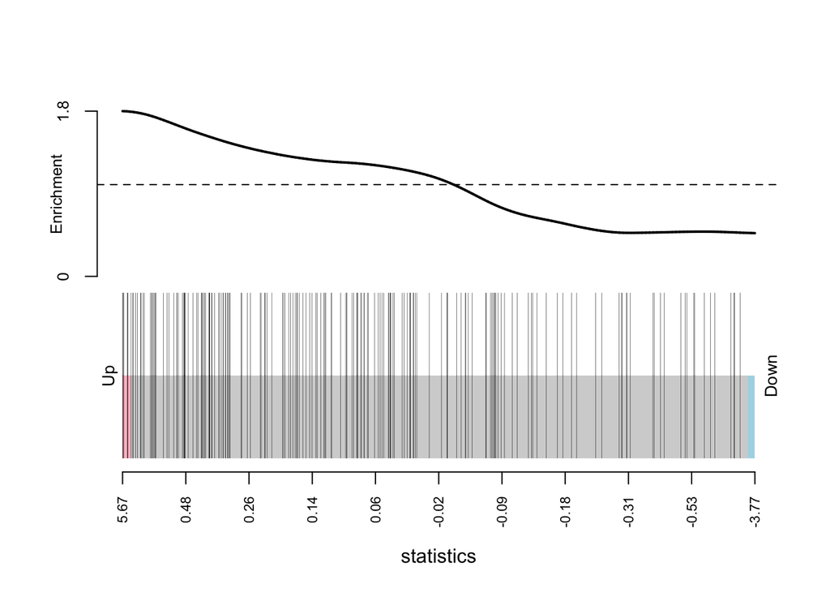

```r
barcodeplot(qlf$table$logFC,
            index = ids2indices(hallmarks, dge$genes$entrez)[["HALLMARK_ADIPOGENESIS"]])
```